# HW3-Sampieri-Pezone

### D = 10

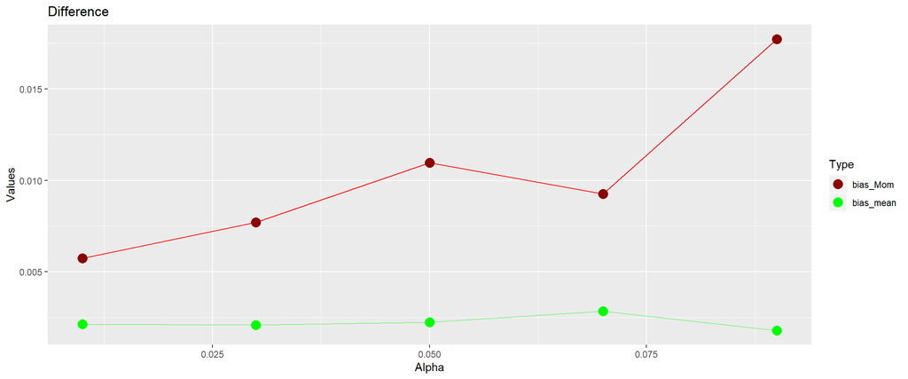

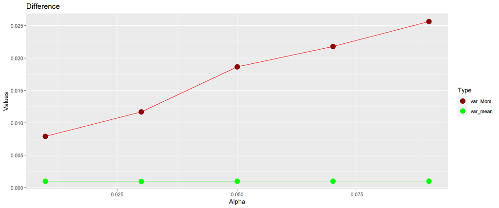

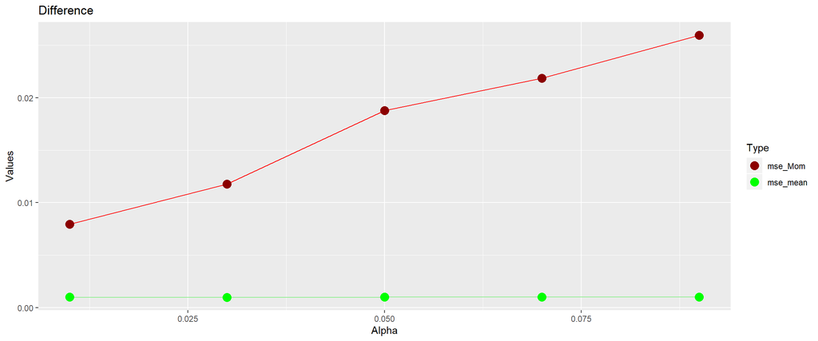

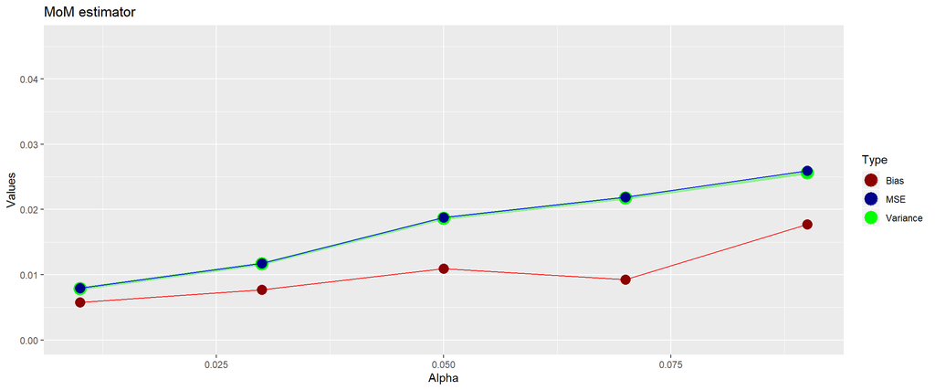

## Weibull Distribution

### D = 2

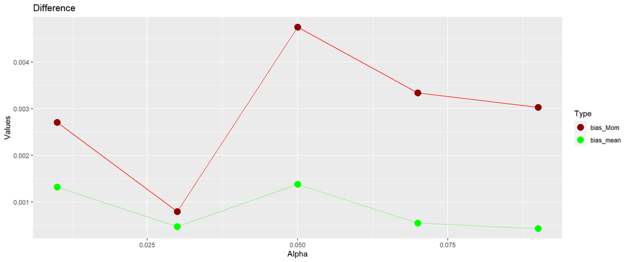

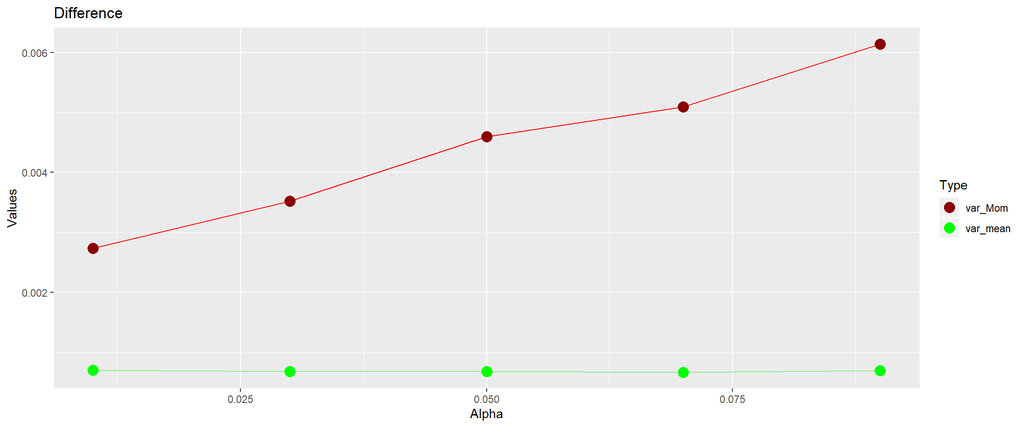

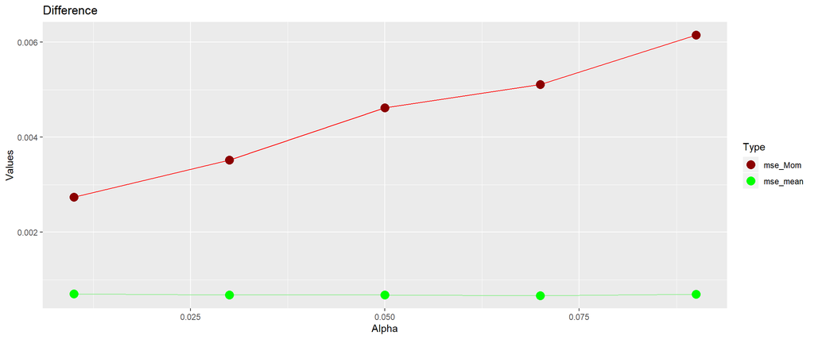

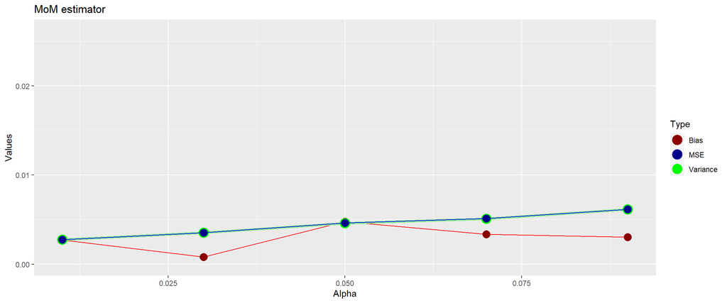

### D = 4

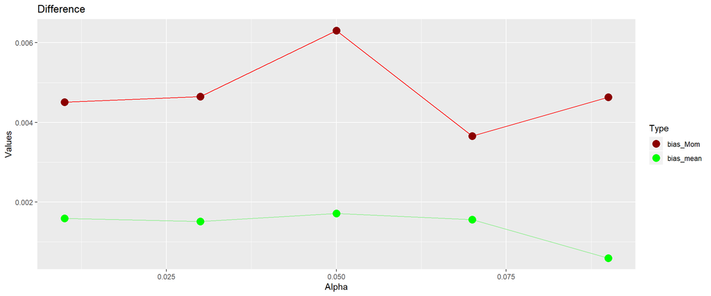

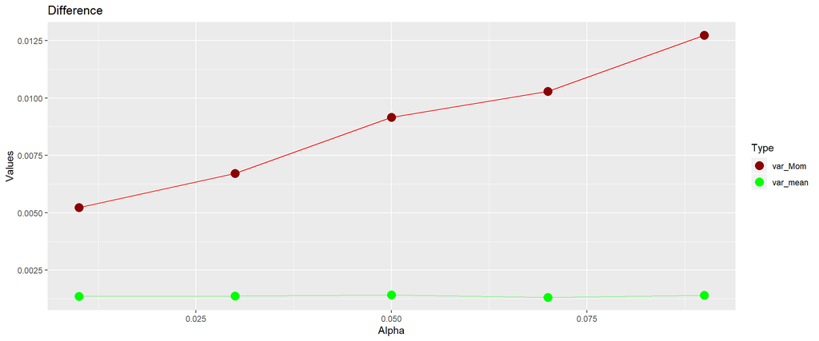

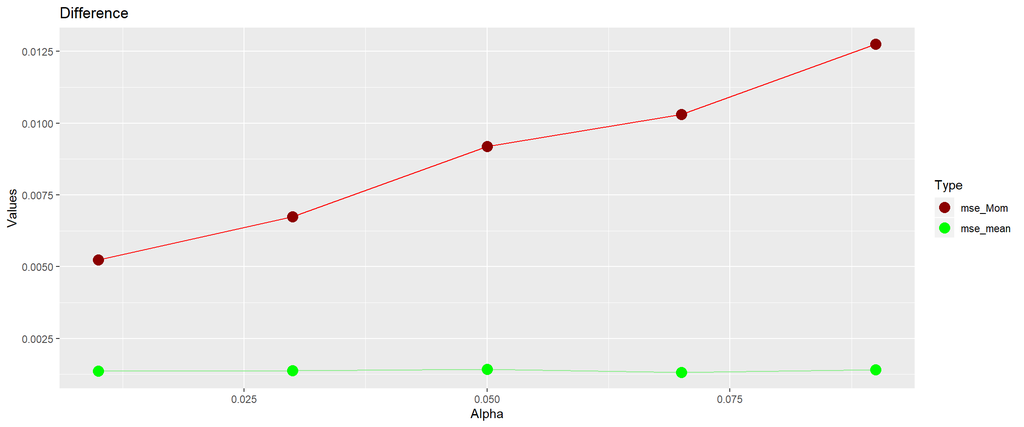

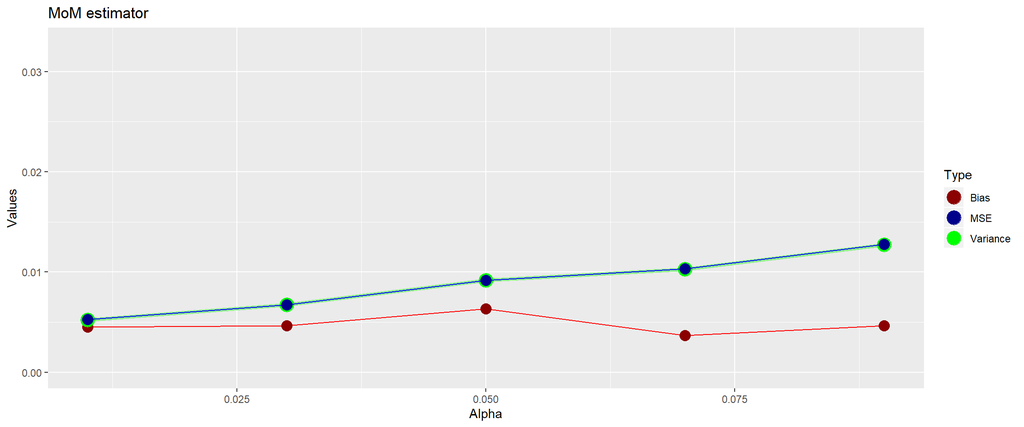

### D = 10

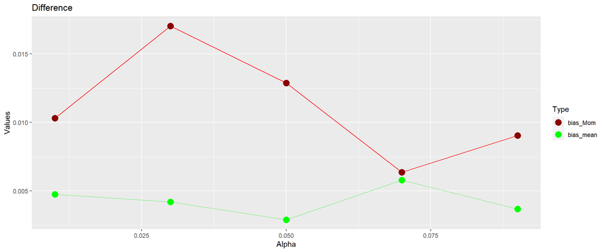

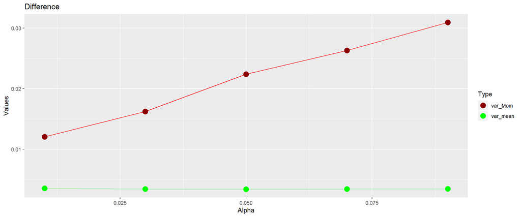

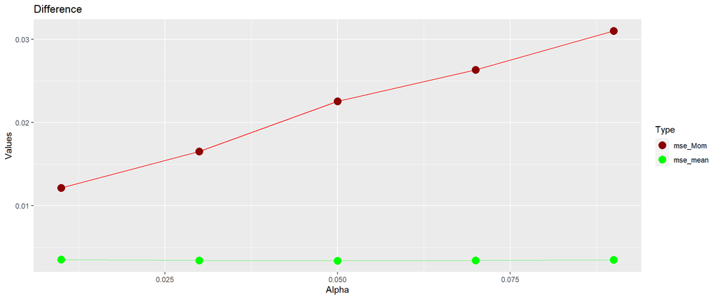

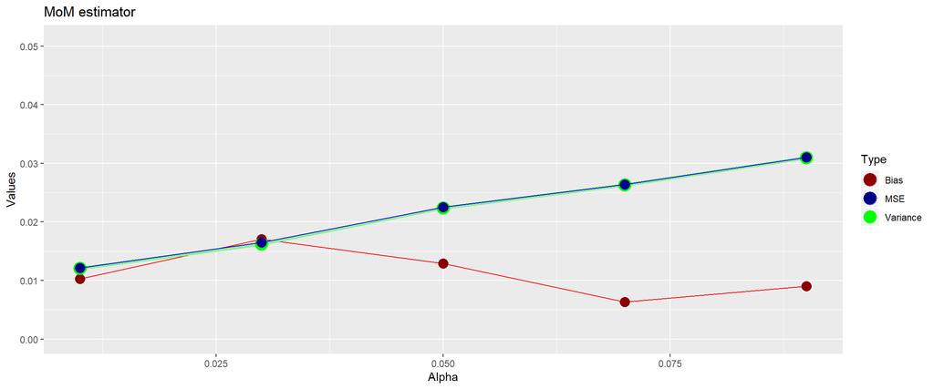

# CRSPday

Now let’s start analyzing our dataframe.

```r
library(zoo)
library(car)
library(PerformanceAnalytics)
library(ggplot2)
library(GGally)
library(ellipse)
library(RColorBrewer)
library(fitdistrplus)
library(MASS)
library(ppcor)
load('C:/Users/franc/Desktop/Data_science/Statistical_Methods_in_Data_Science_and_Laboratory/Homework/hw3/CRSPday.RData')
crsp = as.data.frame(CRSPday)

# Create new date column
crsp$date <- as.Date(with(crsp, paste(year, month, day,sep="-")), "%Y-%m-%d")
dates = crsp$date
```

For simplicity of reading we are going to write some functions representing plots of timeseries and histograms.

```r
plot_var = function(variable, dates){
  par(mfrow=c(1,2))
  plot(zoo(variable,as.Date(dates,"%d/%m/%y")),
       ylab='Values', xlab='Date',
       sub='Timeserie', ylim=c(-.1,.1),col='darkseagreen2', font.sub=3)
  abline(h=c(mean(variable), sd(variable),-sd(variable)),
         col=c('red',"blue",'blue'), lwd=2, lty=c(1,2,2))

  hist(variable,prob=T, col='papayawhip', breaks=50,
       sub='Histogram', xlab='Values', main='', font.sub=3)
  lines(density(variable), col='orange1',lwd=4)
  par(mfrow=c(1,1))
}
```

## Analysis of the variables individually

Let’s analyze the behavior of the individual variables. For each we report the time series, a histogram, the Cullen and Frey graph (to try to deduce the starting distribution) and the qqplot (to analyze the quantiles by comparing them with a normal distribution). Since none of the variables comes close to a generalized extreme value (GEV) distribution (family of distributions which also includes Weibull), the calculation of the Hill’s estimator does not add any information. To evaluate the heaviness of the tails we used the Kurtosis value, which if higher than 3 indicates distributions with heavy tails.

### Ge

In the Cullen and Frey graph we can see how the distribution is no known distribution. Some distributions of the bootstraped approach a logistic but are still very different.

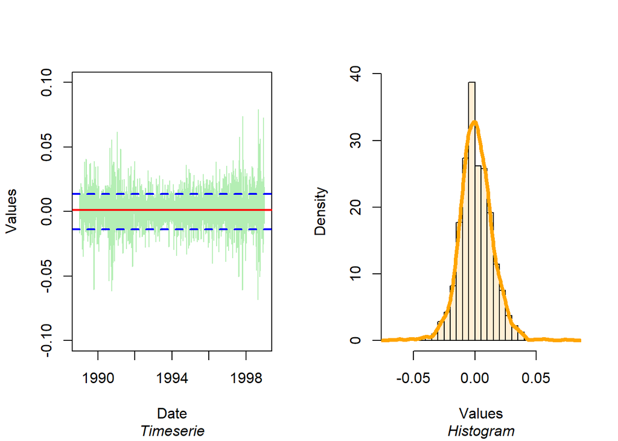

```
## summary statistics
## ------
## min:  -0.068413   max:  0.079077
## median:  0
## mean:  0.00107138
## estimated sd:  0.0137192
## estimated skewness:  0.1346885
## estimated kurtosis:  5.41136
```

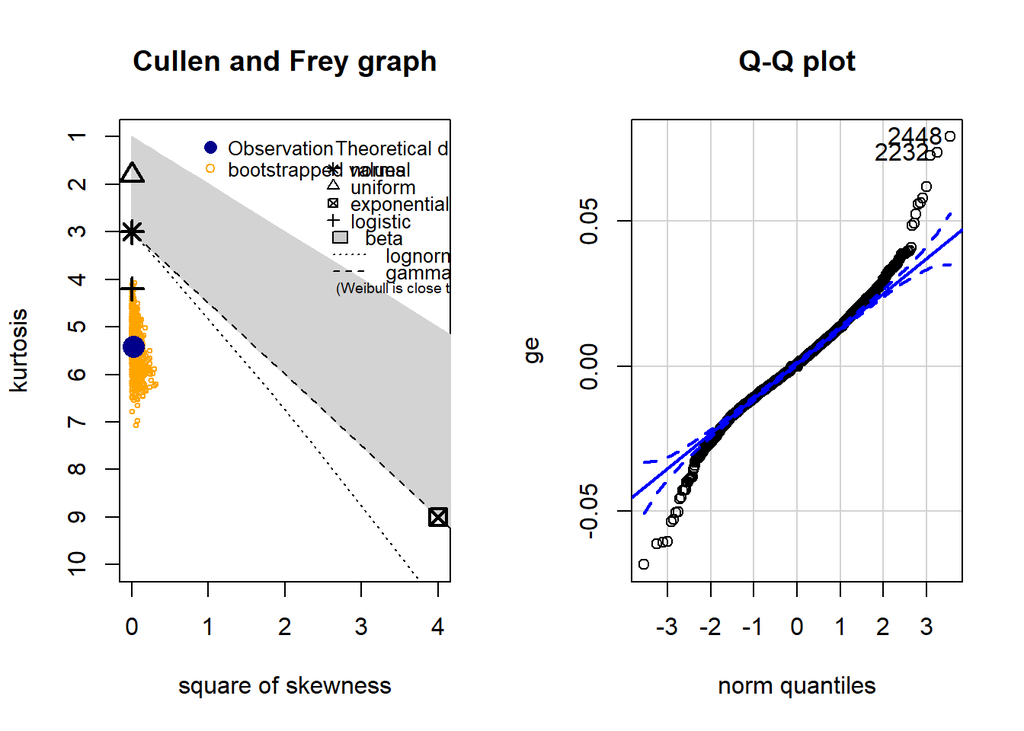

```
## [1] 2448 2232
```

### Ibm

In the Cullen and Frey graph we can see how the distribution is no known distribution. The bootstraped version also differs greatly from known distributions.

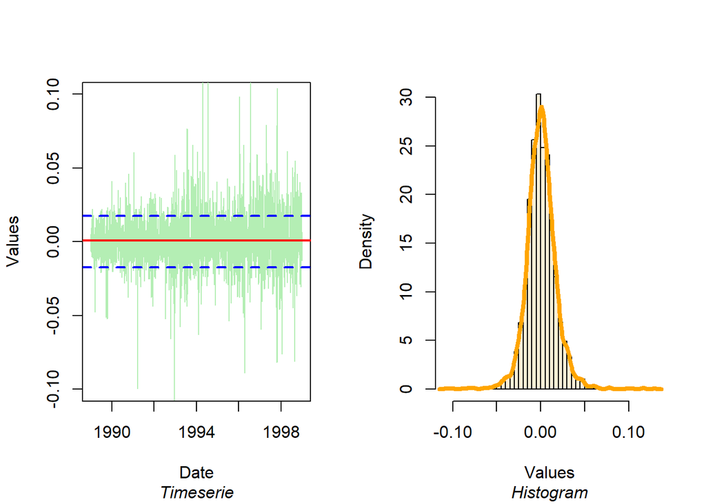

```
## summary statistics
## ------
## min:  -0.107356   max:  0.129428
## median:  0
## mean:  0.0007000767
## estimated sd:  0.0174966
## estimated skewness:  0.389077
## estimated kurtosis:  8.936851
```

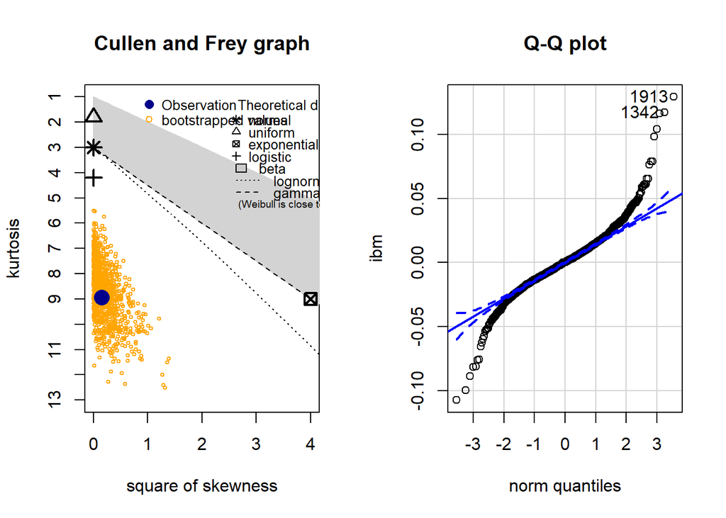

```
## [1] 1913 1342
```

### Mobil

In the Cullen and Frey graph we can see how the distribution is no known distribution. Some distributions of the bootstraped approach a logistic but are still very different.

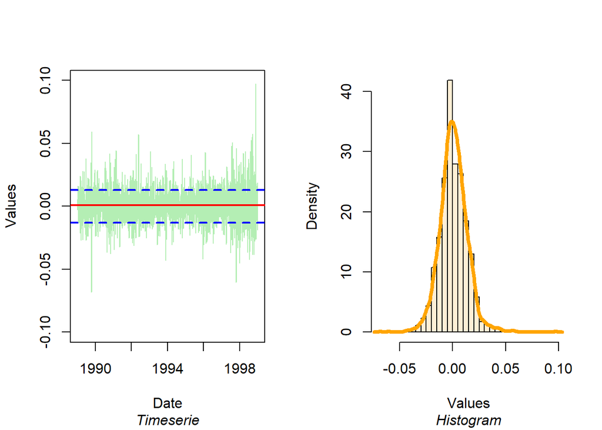

```
## summary statistics
## ------
## min:  -0.068085   max:  0.097289
## median:  0
## mean:  0.0007788801
## estimated sd:  0.01292387
## estimated skewness:  0.3166176
## estimated kurtosis:  5.696665
```

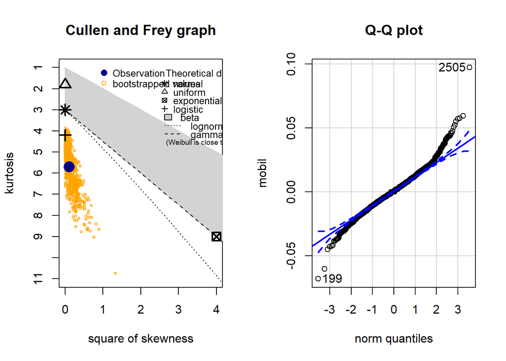

```
## [1] 2505  199
```

### Crsp

In the Cullen and Frey chart we can see how the distribution is unknown. Even the bootstrap version is very poor for the graph, we cannot attribute this data to any known distribution.

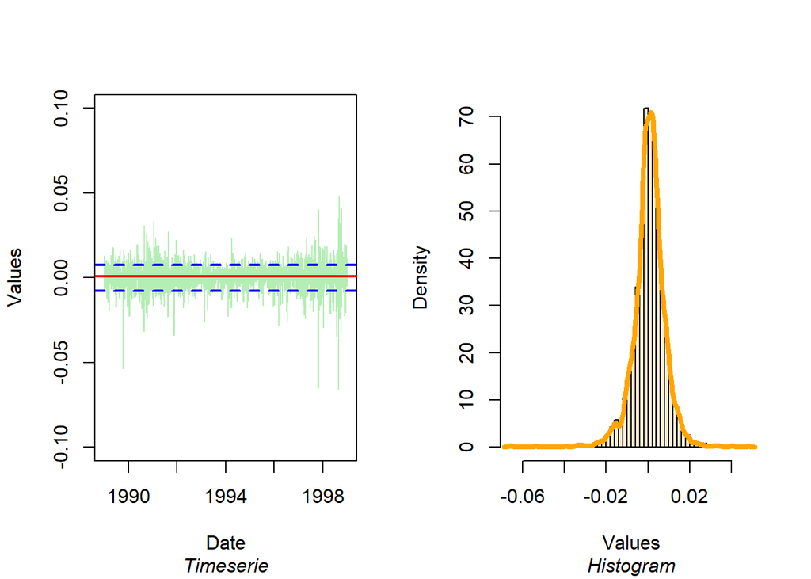

```
## summary statistics
## ------
## min:  -0.065865   max:  0.048189
## median:  0.000929
## mean:  0.0006784691
## estimated sd:  0.007758303
## estimated skewness:  -0.6950143
## estimated kurtosis:  10.66301
```

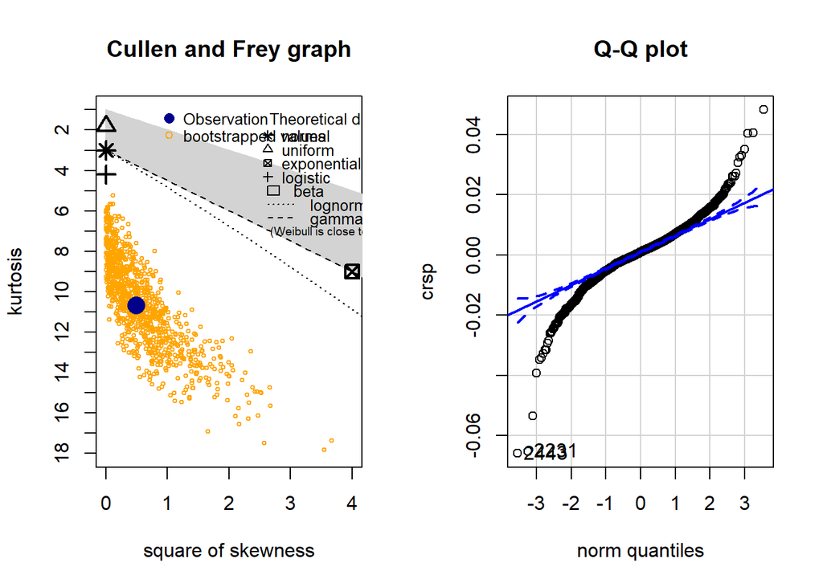

```
## [1] 2443 2231
```